# Визуализация биомедицинских данных. Домашнее задание

# О задании

В этом задании почти соблюдаются принципы классицизма: одно задание — не меньше одного графика и не меньше одного чанка, если не сказано иное. Правило действует, даже когда задание просит вернуться к предыдущему графику. При этом вы всегда можете расширить интерпретацию или показать то же самое ещё и другим, более подходящим, на ваш взгляд, способом — дополнительными графиками к заданию. Некоторые пункты касаются того, о чём на занятиях прямо не говорили, и потребуют справки и документации; обычно такие места оговорены в условии явно.

Инструкция по сдаче задания указана в `README.md` и на Stepik

## **Общие требования к оформлению**

1. Старайтесь соблюдать единый стиль оформления и структуру отчёта, если в задании не указано иное. Не оставляйте в финальном отчёте лишние чанки кода, текст или комментарии, которые не относятся к решению задания.
2. Любой output должен быть читаемым и достаточно кратким, чтобы было удобно просматривать. Не оставляйте «полотна» текста или вывода. Объёмный output оформите аккуратно, либо сократите, либо вовсе уберите. Таблицы оформляйте c пмощью flextable, а для графиков подбирайте подходящий размер и пропорции
3. Ответы на вопросы оформляйте в виде текста явно, не в виде комментариев к коду.
4. Сохраняйте исходную структуру проекта в репозитории. Не добавляйте лишние файлы, которые не относятся к проекту или выполнению заданий.
5. Оформление коммитов и веток на GitHub должно соответствовать общим правилам для всех курсов Института биоинформатики (см. соответствующий материал на курсе Python).

# Правила и требования для всех задач *в этом домашней задании*

**Выполняйте их, даже если в тексте задания они не упомянуты.**

- Под каждым графиком напишите интерпретацию: что на нём видно и какой вывод из этого следует, в 2–4 предложениях. Перечисление геомов и цветов интерпретацией не считается. Если вывода нет или данных для него мало, так и напишите.
- Делайте текст на графике настолько крупным, насколько позволяют сам график и ваше чувство меры. Читаемые надписи — важный (но не так уж часто встречающийся) элемент графиков.
- Не используйте фон ggplot2 по умолчанию.
- У каждого графика должен быть заголовок, отражающий его суть, и правильно названные оси.
- Все подписи на графиках — на русском языке.
- Старайтесь, чтобы графики были достаточно крупными и читались не только в отрендеренном HTML, но и при интерактивном запуске чанков в Positron.
- Однотипные графики стройте функцией (конспект 2, раздел «П6 · Функция для однотипных графиков (слайд П6)»).
- Цвета факультетов — как в конспектах: Гриффиндор `#B32025`, Хаффлпафф `#D7A900`, Рейвенкло `#2E5EAA`, Слизерин `#2F7D4A`. В задании 10 цвета берите с образца.

Для некоторых заданий понадобится пакет patchwork: он собирает несколько графиков в один (конспект 2, раздел «П9 · Несколько графиков на одну страницу (слайд П9)»). Советуем почитать его документацию и пользоваться им в домашней работе. Для задания 8 нужен пакет gghighlight. Если каких-то пакетов нет, установите их один раз в консоли: `install.packages(c("patchwork", "gghighlight"))`.

Если, пока вы строите и интерпретируете график, у вас появилась гипотеза, не стесняйтесь её проверить: постройте для того же задания ещё один график (или несколько), проведите дополнительное исследование.

# Подготовка

```r
library(tidyverse)
library(patchwork)
library(gghighlight)

hogwarts <- read_csv("data/hogwarts_2026.csv", show_col_types = FALSE)
```

```r
# заготовленные функции для одинакового стиля и перевода графиков
house_labels <- c(
  "Gryffindor" = "Гриффиндор",
  "Hufflepuff" = "Пуффендуй",
  "Ravenclaw" = "Когтевран",
  "Slytherin" = "Слизерин"
)

house_colors <- c(
  "Gryffindor" = "#B32025",
  "Hufflepuff" = "#D7A900",
  "Ravenclaw" = "#2E5EAA",
  "Slytherin" = "#2F7D4A"
)

scale_house <- function() {
  scale_fill_manual(
    name = "Факультет",
    values = house_colors,
    labels = house_labels
  )
}

scale_color_house <- function() {
  scale_color_manual(
    name = "Факультет",
    values = house_colors,
    labels = house_labels
  )
}

my_theme <- function() {
  theme_minimal(base_size = 15) +
    theme(
      panel.background = element_rect(fill = "#D0C9BE"),
      plot.background = element_rect(fill = "#D0C9BE"),
      legend.background = element_rect(fill = "#D0C9BE"),
      text = element_text(family = "serif"),
      plot.title = element_text(
        size = 20,
        face = "bold",
        hjust = 0.5,
        family = "serif",
        color = "#5A4638"
      ),
      axis.title = element_text(face = "bold", size = 18, color = "#5A4638"),
      axis.text = element_text(size = 18, face = "bold"),
      legend.title = element_text(size = 18, face = "bold"),
      legend.text = element_text(size = 15, family = "serif"),
      legend.position = "top"
    )
}
```

# Задание 1

Постройте барплот (столбчатую диаграмму), отражающий распределение числа студентов по курсам обучения. Раскрасьте столбики любым понравившимся цветом: подойдёт и название цвета, и hex-код. Задайте и цвет контура столбиков. Проинтерпретируйте график.

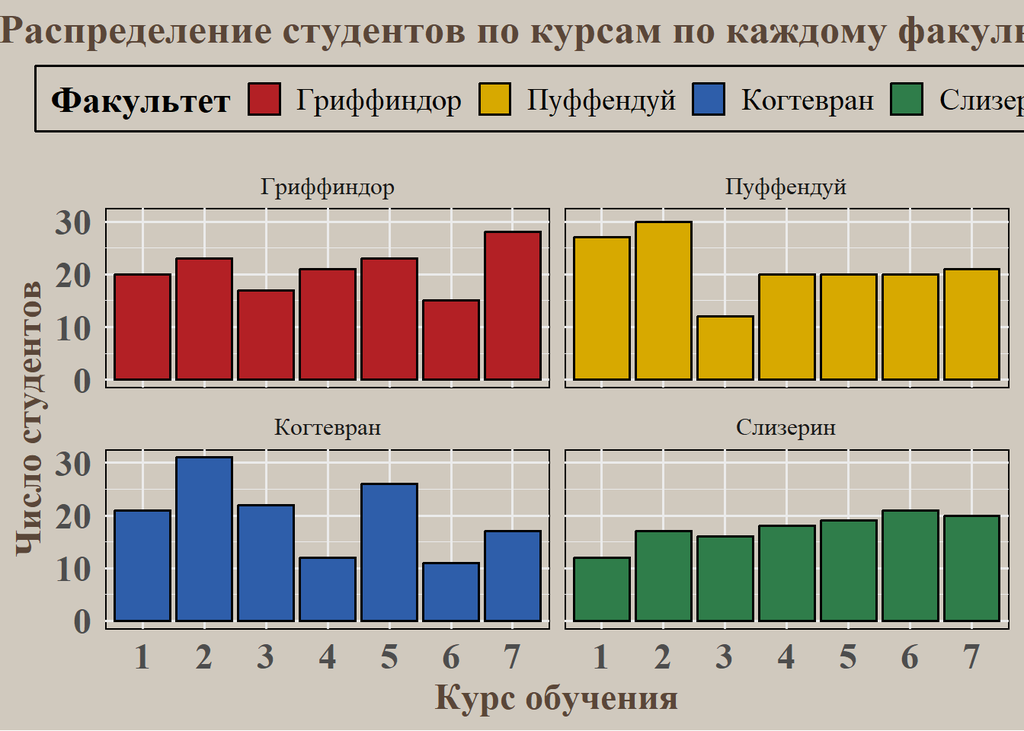

```r
plot1 <- ggplot(data = hogwarts, aes(x = factor(course), fill = house)) +
  geom_bar(color = "black", position = "dodge") +
  scale_fill_manual(
    values = c(
      "Gryffindor" = "#B32025",
      "Hufflepuff" = "#D7A900",
      "Ravenclaw" = "#2E5EAA",
      "Slytherin" = "#2F7D4A"
    ),
    labels = c(
      "Gryffindor" = "Гриффиндор",
      "Hufflepuff" = "Пуффендуй",
      "Ravenclaw" = "Когтевран",
      "Slytherin" = "Слизерин"
    )
  ) +
  labs(
    title = "Распределение студентов по курсам по каждому факультету",
    x = "Курс обучения",
    y = "Число студентов",
    fill = "Факультет"
  ) +
  facet_wrap(~house, labeller = as_labeller(house_labels)) +
  my_theme() +
  scale_house()
plot1
```

**Интерпретация:** … График показывает столбчатые диаграммы для каждого курса каждого факультета. по оси x - года обучения, по оси y = число студентов.

# Задание 2

Постройте новый барплот, отражающий распределение числа студентов по факультетам. Добавьте на график вторую факторную переменную — происхождение (`bloodStatus`).

С помощью аргумента `position` измените график так, чтобы каждый столбец показывал распределение факультета по чистоте крови в долях. Запишите текстом в этом файле, какой вывод можно сделать из графика.

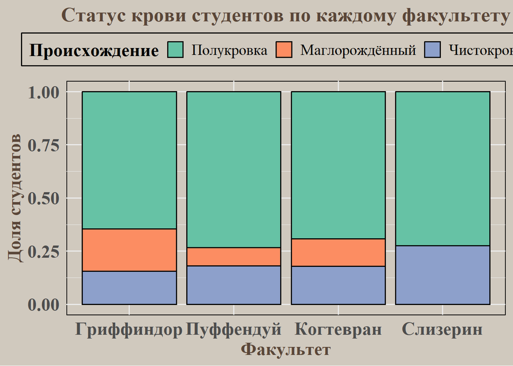

```r
plot2 <- ggplot(data = hogwarts, aes(x = factor(house), fill = bloodStatus)) +
  geom_bar(color = "black", position = "fill") +
  scale_fill_brewer(
    palette = "Set2",
    name = "Происхождение",
    labels = c(
      "half-blood" = "Полукровка",
      "muggle-born" = "Маглорождённый",
      "pure-blood" = "Чистокровный"
    )
  ) +
  scale_x_discrete(
    labels = c(
      "Gryffindor" = "Гриффиндор",
      "Hufflepuff" = "Пуффендуй",
      "Ravenclaw" = "Когтевран",
      "Slytherin" = "Слизерин"
    )
  ) +
  labs(
    title = "Статус крови студентов по каждому факультету",
    x = "Факультет",
    y = "Доля студентов"
  ) +
  my_theme()

plot2
```

Отобразите распределение баллов, заработанных студентами на 3-й неделе обучения, по факультетам. Постарайтесь показать одновременно и форму распределения, и некоторые описательные статистики. Отсортируйте факультеты в порядке убывания медианного балла за 3-ю неделю (функция, которую мы разбирали на слайде 21, по умолчанию сортирует именно по медиане, так что задавать медиану отдельным аргументом не нужно). Если используете `geom_jitter()`, постарайтесь, чтобы точки лежали кучнее вдоль оси, которая не отражает само распределение. Проинтерпретируйте график.

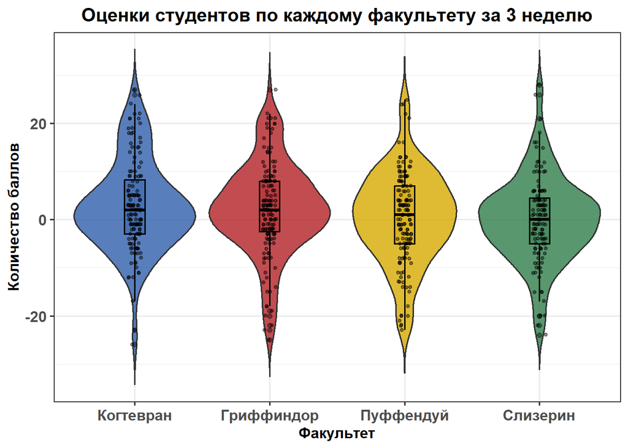

```r
plot3 <- ggplot(
  data = hogwarts,
  aes(x = reorder(house, -week_3), y = week_3, fill = house)
) +
  geom_violin(trim = FALSE, alpha = 0.8) +
  geom_boxplot(alpha = 0.4, width = 0.15, color = "black") +
  geom_jitter(width = 0.05, size = 1, alpha = 0.4, height = 0.1) +
  scale_fill_manual(
    name = "Факультет",
    values = c(
      "Gryffindor" = "#B32025",
      "Hufflepuff" = "#D7A900",
      "Ravenclaw" = "#2E5EAA",
      "Slytherin" = "#2F7D4A"
    ),
    labels = c(
      "Gryffindor" = "Гриффиндор",
      "Hufflepuff" = "Пуффендуй",
      "Ravenclaw" = "Когтевран",
      "Slytherin" = "Слизерин"
    )
  ) +
  scale_x_discrete(
    labels = c(
      "Gryffindor" = "Гриффиндор",
      "Ravenclaw" = "Когтевран",
      "Hufflepuff" = "Пуффендуй",
      "Slytherin" = "Слизерин"
    )
  ) +
  labs(
    title = "Оценки студентов по каждому факультету за 3 неделю",
    x = "Факультет",
    y = "Количество баллов"
  ) +
  theme_bw(base_size = 12) +
  theme(
    plot.title = element_text(size = 15, face = "bold", hjust = 0.5),
    axis.title = element_text(size = 12, face = "bold"),
    axis.text = element_text(size = 12, face = "bold"),
    #legend.title = element_text(size = 18, face = "bold"),
    #legend.text = element_text(size = 15),
    legend.position = "none"
  )
plot3
```

**Интерпретация:** … На 3 графике я изобразил распределение оценок студентов за 3 неделю. violin plot выглядит шире там в тех значениях, которые встречаются чаще. Легенда убрана. у студентов встречаются отрицательные значение баллов. формы распределения относительно похожи между факультетами. Они симметричны. 75% процентиль Слизерина заметно ниже, чем у остальных факультетов.

# Задание 4

Постройте гистограмму результатов любого экзамена на ваш выбор, кроме зельеварения. Настройте оптимальное, на ваш взгляд, число столбцов гистограммы. Выполните фасетирование по курсу. Постарайтесь, чтобы график был по возможности компактным. Проинтерпретируйте график.

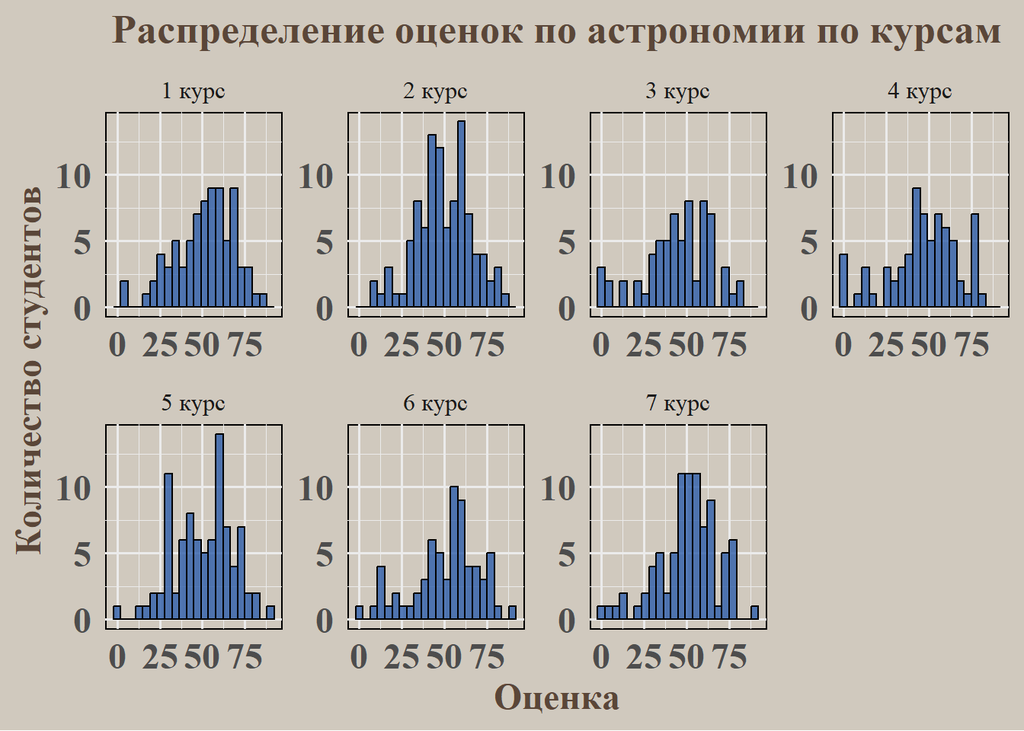

```r
plot4 <- ggplot(
  data = hogwarts,
  aes(x = `Astronomy exam`)
) +
  geom_histogram(
    color = "black",
    fill = "#2E5EAA",
    bins = 22,
    alpha = 0.8,
    linewidth = 0.4
  ) +
  facet_wrap(
    ~course,
    ncol = 4,
    axes = "all",
    labeller = as_labeller(function(x) paste0(x, " курс"))
  ) +
  scale_house() +
  labs(
    title = "Распределение оценок по астрономии по курсам",
    x = "Оценка",
    y = "Количество студентов"
  ) +
  my_theme()
plot4
```

**Интерпретация:** … На этом графике мы не видим распределения по факультетам. Распределение оценок общее и различается только по курсам, очень приблизительно напоминает нормальное по всем курсам, однако оно немного скошено влево. Размер бина установлен = 22.

# Задание 5

Постройте скаттерплот, показывающий связь между суммарным баллом студента за год и оценкой за экзамен (по травологии, магловедению, нумерологии и зельеварению). Добавьте на график линию тренда. Удалите доверительную область и сделайте линию прямой. Подумайте, как обойтись без того, чтобы записывать одни и те же координаты x и y дважды. Проинтерпретируйте график.

Раскрасьте точки в разные цвета в соответствии с факультетами. Проинтерпретируйте полученный результат.

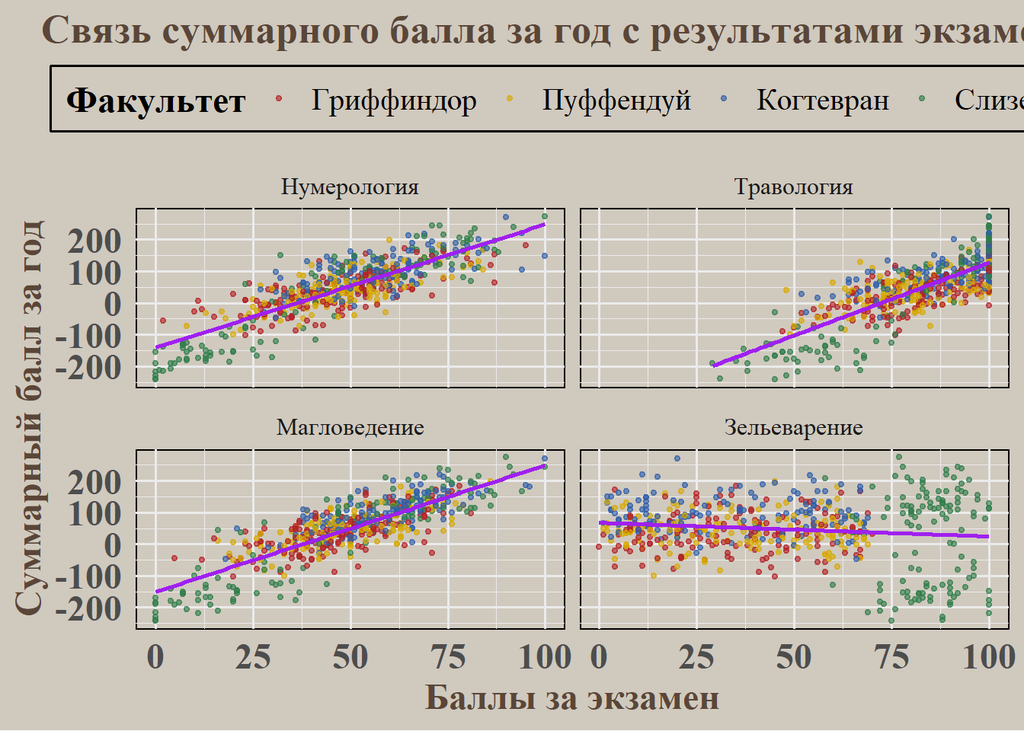

```r
exams_plot5 <- hogwarts |>
  select(
    house,
    result,
    `Herbology exam`,
    `Muggle studies exam`,
    `Arithmancy exam`,
    `Potions exam`
  ) |>
  pivot_longer(
    cols = c(
      `Herbology exam`,
      `Muggle studies exam`,
      `Arithmancy exam`,
      `Potions exam`
    ),
    names_to = "exam",
    values_to = "exam_score"
  )
exam_names <- c(
  "Herbology exam" = "Травология",
  "Muggle studies exam" = "Магловедение",
  "Arithmancy exam" = "Нумерология",
  "Potions exam" = "Зельеварение"
)

plot5 <- ggplot(
  data = exams_plot5,
  aes(x = exam_score, y = result)
) +
  geom_point(aes(color = house), alpha = 0.6, size = 1.0) +
  geom_smooth(method = "lm", se = FALSE, linewidth = 1, color = "purple") +
  facet_wrap(~exam, ncol = 2, labeller = as_labeller(exam_names)) +
  scale_color_house() +
  labs(
    title = "Связь суммарного балла за год с результатами экзаменов",
    x = "Баллы за экзамен",
    y = "Суммарный балл за год"
  ) +
  my_theme()
plot5
```

**Интерпретация:** … для того, чтобы найти связь с данными из нескольких колонок, пришлось привести данные к лонг-формату. можно увидеть, что для 3 предметов есть положительная связь между оценкой за предмет и общей успеваемостью за год, однако это не работает с зельеварением. там линия идет даже на легкое убывание. студенты слизерина при этом кластеризуются на 2 группы по обе стороны от линии. По остальным предметам, студенты слизерина также разделяются на 2 группы, одна из которых ближе всех к началу координатной сетки, то есть имеют самые низкие общие и предметные баллы. Также, видно что непропорционально много студентов, имеющих высший балл по травологии.

# Задание 6

Сравните распределение баллов за экзамен по прорицанию и за экзамен по защите от тёмных искусств. Сделайте это тремя разными способами. Под разными способами понимаются идеологически разные геомы или способы группировки. Не считаются разными способами изменения константных визуальных параметров (цвет заливки, размер фигур, другие чисто стилевые отличия) на сходных в остальном графиках.

Объедините графики так, чтобы итоговый график имел два столбца и две строки. Два графика должны стоять в верхней строке и занимать равную площадь. Третий график должен занимать нижнюю строку целиком. Проинтерпретируйте график.

[figure not shown]

```r
library(patchwork)
exams_plot6 <- hogwarts |>
  select(
    `Defence against the dark arts exam`,
    `Divinations exam`
  ) |>
  pivot_longer(
    cols = c(`Defence against the dark arts exam`, `Divinations exam`),
    names_to = "exam",
    values_to = "score"
  ) |>
  mutate(
    exam = recode(
      exam,
      "Divinations exam" = "Прорицания",
      "Defence against the dark arts exam" = "Защита от тёмных искусств"
    )
  )

plot6 <- ggplot(exams_plot6, aes(x = score, fill = exam, color = exam)) +
  geom_density(alpha = 0.4, linewidth = 0.8) +
  scale_fill_manual(
    name = "Предмет",
    values = c(
      "Прорицания" = "#946B2D",
      "Защита от тёмных искусств" = "#740001"
    )
  ) +
  scale_color_manual(
    name = "Предмет",
    values = c(
      "Прорицания" = "#946B2D",
      "Защита от тёмных искусств" = "#740001"
    )
  ) +
  labs(
    title = "Сравнение оценивания Прорицания и Защиты от темных искусств",
    x = "Баллы за экзамен",
    y = NULL
  ) +
  my_theme()

plot6_2 <- ggplot(exams_plot6, aes(x = exam, y = score, fill = exam)) +
  geom_boxplot(width = 0.35, alpha = 0.5, outlier.shape = NA, color = "black") +
  geom_jitter(width = 0.12, alpha = 0.25, size = 1.2, color = "#2B1B17") +
  scale_fill_manual(
    name = "Предмет",
    values = c(
      "Прорицания" = "#946B2D",
      "Защита от тёмных искусств" = "#740001"
    )
  ) +
  labs(
    title = "Боксплот распределения",
    x = NULL,
    y = "Баллы за экзамен"
  ) +
  my_theme() +
  theme(legend.position = "none")


plot6_3 <- ggplot(exams_plot6, aes(x = exam, y = score, fill = exam)) +
  geom_violin(
    alpha = 0.5,
    color = "black",
    linewidth = 0.6,
    draw_quantiles = c(0.25, 0.5, 0.75)
  ) +
  scale_fill_manual(
    name = "Предмет",
    values = c(
      "Прорицания" = "#946B2D",
      "Защита от тёмных искусств" = "#740001"
    )
  ) +
  labs(
    title = "Виолин плот распределения",
    x = "Баллы за экзамен",
    y = NULL
  ) +
  my_theme() +
  theme(legend.position = "none")


final_plot6 <- (plot6_3 + plot6_2) /
  plot6 +
  plot_annotation(
    theme = theme(
      plot.title = element_text(face = "bold", size = 15, hjust = 0.5)
    )
  ) &
  theme(
    axis.title = element_blank(),
  )
final_plot6
```

**Интерпретация:** … Оценки по Прорицанию заметно нижк оценок по защите от темных искусств по медиане, межквартильному разбросу, а также имеют меньший разброс. Оценки по защите от темных искусств имеют 2 пика, в то время как Прорицания лишь один.

# Задание 7

Постройте диаграмму рассеяния (скаттерплот), где по осям отложены результаты экзаменов по заклинаниям и по древним рунам. На графике есть некоторая проблема. Если вам трудно её определить, возьмите подсказку: постройте скаттерплот по данным из файла `data/podskazka.csv`. По оси x отложите переменную `y`, по оси y — переменную `x`, а пределы оси y задайте от 200 до 500. Предложите и подкрепите визуализациями не менее трёх способов решить эту проблему.

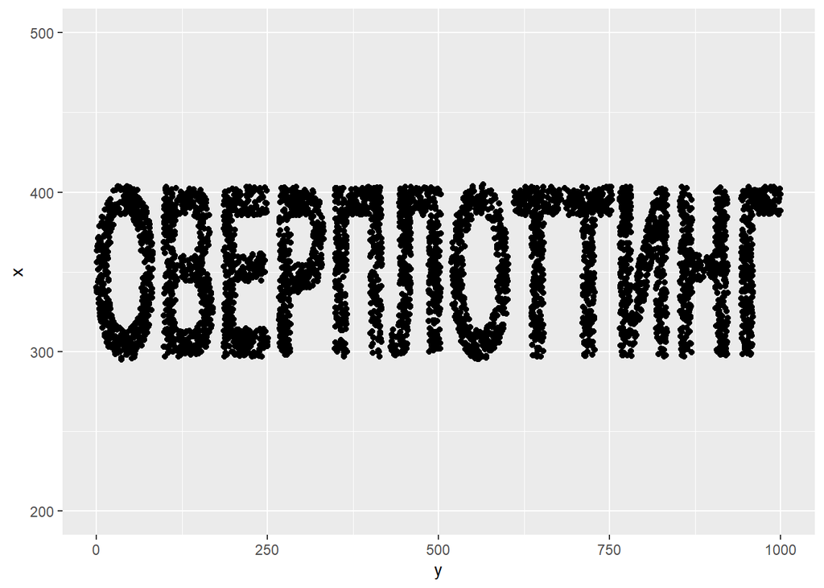

```r
podskazka <- read_csv("data/podskazka.csv")

ggplot(podskazka, aes(x = y, y = x)) +
  geom_point() +
  ylim(200, 500)
```

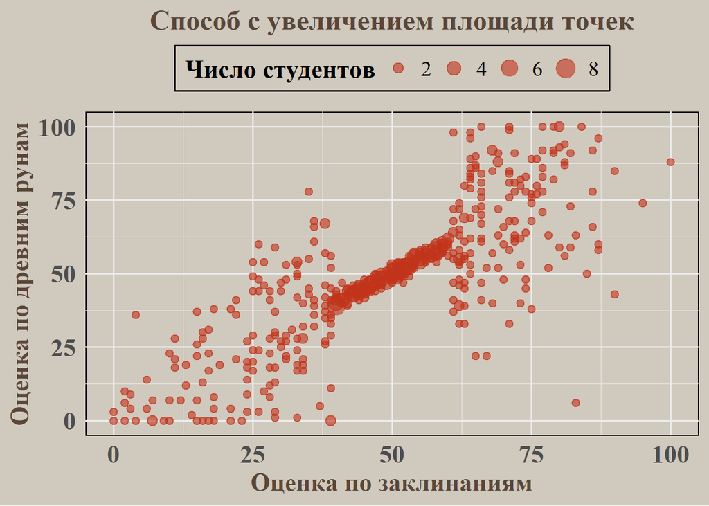

```r
###################################################

plot7_1 <- ggplot(
  hogwarts,
  aes(x = `Charms exam`, y = `Study of ancient runes exam`)
) +
  geom_count(alpha = 0.6, color = "#c1331a") +
  scale_size_area(max_size = 6, name = "Число студентов") +
  xlim(0, 100) +
  ylim(0, 100) +
  labs(
    title = "Способ с увеличением площади точек",
    x = "Оценка по заклинаниям",
    y = "Оценка по древним рунам"
  ) +
  my_theme()

plot7_1
```

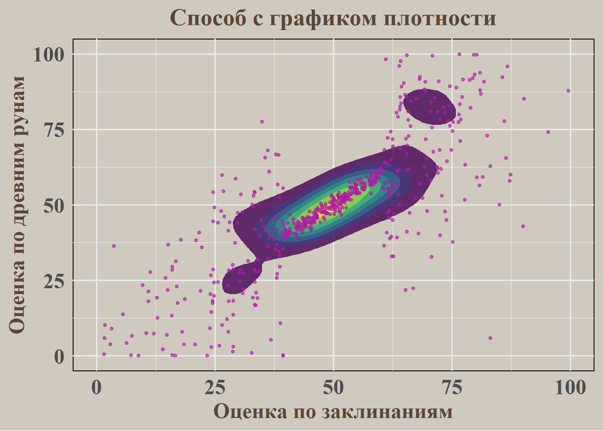

```r
plot7_2 <- ggplot(
  hogwarts,
  aes(x = `Charms exam`, y = `Study of ancient runes exam`)
) +
  stat_density_2d(
    aes(fill = after_stat(level)),
    geom = "polygon",
    alpha = 0.8
  ) +
  geom_jitter(
    width = 0.5,
    height = 0.5,
    alpha = 0.6,
    size = 1,
    color = "#ad1ca3"
  ) +
  scale_fill_viridis_c(guide = "none") +
  xlim(0, 100) +
  ylim(0, 100) +
  labs(
    title = "Способ с графиком плотности",
    x = "Оценка по заклинаниям",
    y = "Оценка по древним рунам"
  ) +
  my_theme()

plot7_2
```

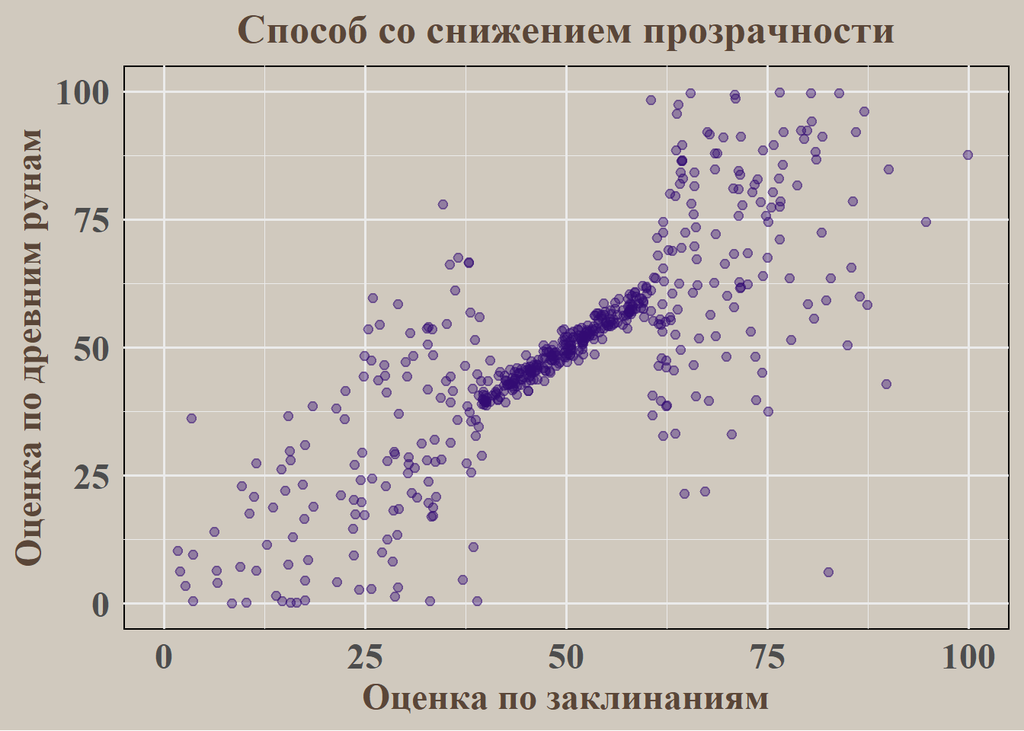

```r
plot7_3 <- ggplot(
  hogwarts,
  aes(x = `Charms exam`, y = `Study of ancient runes exam`)
) +
  geom_jitter(
    width = 0.6,
    height = 0.6,
    alpha = 0.4,
    size = 1.8,
    color = "#320a72"
  ) +
  xlim(0, 100) +
  ylim(0, 100) +
  labs(
    title = "Способ со снижением прозрачности",
    x = "Оценка по заклинаниям",
    y = "Оценка по древним рунам"
  ) +
  my_theme()

plot7_3
```

**Проблема и способы её решения:** … при картировании данных с двух колонок на одну 2Д плоскость, многие из них будут группироваться в одних и тех же местах, закрывая друг ддруга и искажая восприятие данных. для этого, надо модифицировать графику. например, можно увеличивать размер точек, если они совпадают (1 график). можно менять уровень прозрачности (3 график). можно построить график плотности значений (2 график)

# Задание 8

Используйте таблицу с баллами по неделям для первых 30 студентов, которую мы получили на занятии (`first_30`, конспект 2, раздел «Линии: `group`, спагетти, акцент, профиль (слайд 53)»). В ней пока нет столбца `bloodStatus`, а он понадобится для подписей. Постройте лайнплоты для всех студентов. Выделите при помощи пакета gghighlight студентов факультета Рейвенкло, на лейблах отразите их происхождение.

# Задание 9

Подробно (останавливаясь на каждом пункте, а не в общем) опишите, какие стороны графика и интерпретации (она приводится ниже) вы считаете верными и сделанными в соответствии с хорошими практиками, а какие — нет. Сделайте свой график, который отвечает на тот же исследовательский вопрос, но лишён технических и интерпретационных недостатков оригинала (если вы таковые нашли и упомянули).

Интерпретация графика:

> В ходе исследования, проведенного в ФГБОУССО «Хогвартс» (далее Хогвартс) для оценки успешности образовательного процесса и психоэмоционального состояния участников вышеназванного процесса, были выявлены тревожные закономерности. А именно — при оценке среднего балла, полученного в течение недели совокупностью учащихся Хогвартса, была выявлена тенденция к резкому снижению данного показателя с течением времени. Так, в начале учебного процесса студенты набирали в среднем 2 балла (максимальный показатель). В последующие недели балл достоверно снижался, достигая минимальных значений к концу года (см. рис. 1). Мы полагаем, что данный процесс связан с ухудшением психологического состояния преподавателей означенного учебного заведения. Таким образом, в течение года они от мотивирующих мер положительного характера (добавление баллов за правильные ответы на занятиях и успехи во внеучебной деятельности) переходят к репрессивным действиям (учащающийся и увеличивающийся по модулю отъем баллов факультета за предполагаемые нарушения дисциплины, недостаточную, по мнению преподавателя, подготовку к занятию и пр.). Это вызывает снижение у учащихся мотивации к получению знаний, что вызывает следующий шаг снижения средненедельного балла — т.о., поведение педагогов вызывает своего рода circulus vitiosus.

> По итогам исследования и с учетом полученных результатов предлагается следующее: произвести замену профессорско-преподавательского состава с заменой педагогов, наиболее подверженных выгоранию в течение года (проявляющемуся в виде систематического снижения баллов студентам). Издать декрет о недопущении избыточного штрафования учащихся, начиная с 18-й недели учебного процесса до конца года. К нарушителям применять взыскания материально-магического характера. Объявить выговор с занесением в личное дело текущим представителям руководящего состава Хогвартса (далее дирекция).

**Разбор графика и интерпретации:** … Проблемы:

Говоря об интерпретации: Очень много словоблудия, смысл теряется уже через пару слов после начала каждого предложения. Наблюдения выводы и дискуссия смешаны в одном абзаце текста. Интерпретация выходит далеко за рамки графика.

Достоинства:

График действительно уникальный, он запоминается и о нем хочется думать. Также идея упорядочивания по оценкам на хронологической шкале звучит довольно любопытной и может быть полезна для вывления зависимостей с другим фактором.

Говоря об интерпретации: Теперь веселее читать уведомления от ЖКХ, зная такой референс. Помимо этого, есть попытки в анализ изображения, хотя и не слишком глубокие.

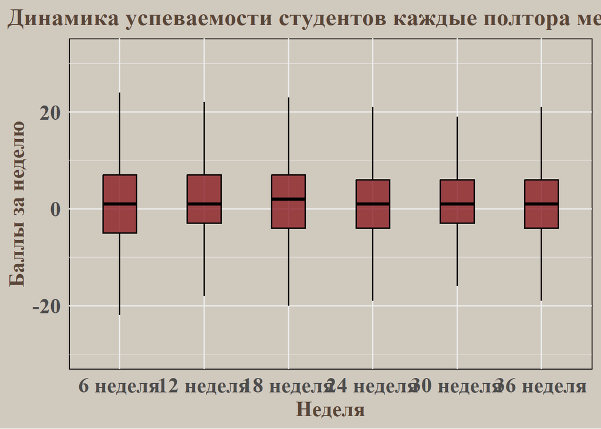

```r
library(tidyverse)

subset_weeks <- paste0("week_", seq(6, 36, by = 6))

plot9_data <- hogwarts |>
  select(id, all_of(subset_weeks)) |>
  pivot_longer(
    cols = all_of(subset_weeks),
    names_to = "week",
    values_to = "score"
  ) |>
  mutate(
    week = factor(
      week,
      levels = subset_weeks,
      labels = paste0(seq(6, 36, by = 6), " неделя")
    )
  )

plot9 <- ggplot(plot9_data, aes(x = week, y = score)) +
  geom_boxplot(
    fill = "#8B1E24",
    outlier.shape = NA,
    color = "black",
    width = 0.4,
    alpha = 0.8,
    linewidth = 0.7,
  ) +

  labs(
    title = "Динамика успеваемости студентов каждые полтора месяца",
    x = "Неделя",
    y = "Баллы за неделю"
  ) +
  my_theme()

plot9
```

# Задание 10 (дополнительное)

Воспроизведите график максимально близко к оригиналу и проинтерпретируйте его. Постарайтесь максимально точно отразить каждый элемент.

Образец лежит в файле `images/task_10.png`:

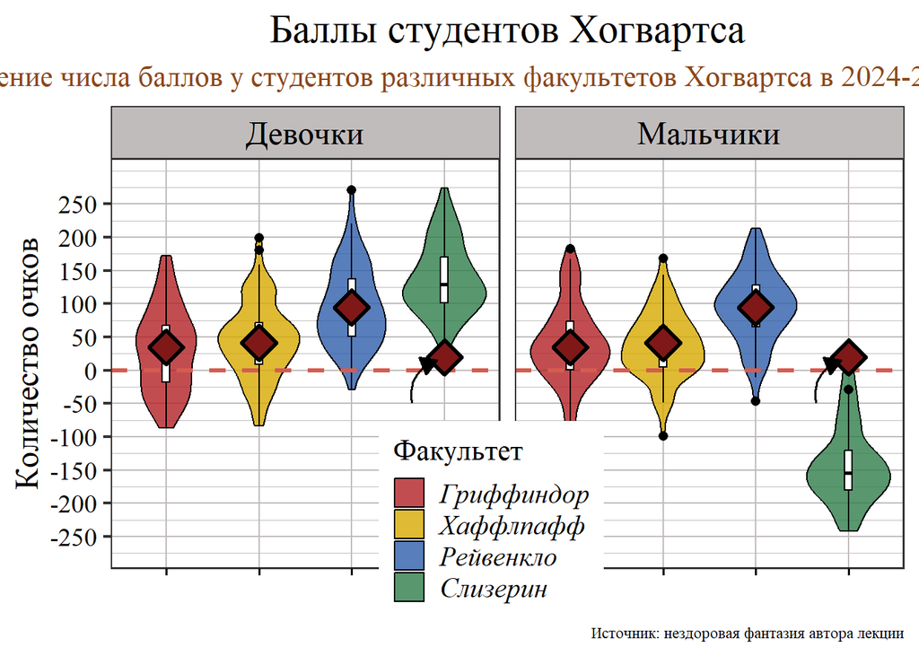

```r
library(tidyverse)

house_colors <- c(
  "Gryffindor" = "#B32025",
  "Hufflepuff" = "#D7A900",
  "Ravenclaw" = "#2E5EAA",
  "Slytherin" = "#2F7D4A"
)
house_levels <- c("Gryffindor", "Hufflepuff", "Ravenclaw", "Slytherin")
house_labels <- c(
  "Gryffindor" = "Гриффиндор",
  "Hufflepuff" = "Хаффлпафф",
  "Ravenclaw" = "Рейвенкло",
  "Slytherin" = "Слизерин"
)

plot10_data <- hogwarts |>
  mutate(
    sex_label = factor(
      sex,
      levels = c("female", "male"),
      labels = c("Девочки", "Мальчики")
    ),
    house = factor(house, levels = house_levels)
  )

plot10 <- ggplot(plot10_data, aes(x = house, y = result)) +
  geom_violin(
    aes(fill = house),
    color = "black",
    alpha = 0.8,
    linewidth = 0.5,
  ) +
  geom_boxplot(
    width = 0.08,
    fill = "white",
    color = "black",
    outlier.shape = 16,
    linewidth = 0.5
  ) +

  geom_hline(
    yintercept = 0,
    linewidth = 1.2,
    color = "#d55c4f",
    linetype = "dashed",
  ) +
  stat_summary(
    data = ~ transform(.x, sex_label = NULL),
    aes(group = house),
    fun = mean,
    geom = "point",
    shape = 23,
    size = 6,
    fill = "#801818",
    color = "black",
    stroke = 1.6
  ) +

  facet_wrap(~sex_label, ncol = 2) +
  scale_fill_manual(
    name = "Факультет",
    values = house_colors,
    labels = house_labels
  ) +
  scale_y_continuous(
    breaks = seq(-250, 250, by = 50),
    limits = c(-270, 290)
  ) +
  geom_curve(
    # тут помог ии
    aes(x = 3.65, y = -50, xend = 3.92, yend = 15),
    curvature = -0.42,
    arrow = arrow(length = unit(0.35, "cm"), type = "closed"),
    color = "black",
    linewidth = 0.6,
    inherit.aes = FALSE
  ) +

  labs(
    title = "Баллы студентов Хогвартса",
    subtitle = "Распределение числа баллов у студентов различных факультетов Хогвартса в 2024-2025 учебном году",
    x = "Факультет",
    y = "Количество очков",
    caption = "Источник: нездоровая фантазия автора лекции"
  ) +
  theme_bw(base_size = 16) +
  theme(
    text = element_text(family = "serif"),
    plot.title = element_text(
      size = 22,
      hjust = 0.5,
      face = "plain",
    ),
    plot.subtitle = element_text(
      size = 16,
      hjust = 0.5,
      color = "#8c461a",
    ),
    plot.caption = element_text(
      size = 8.5,
      color = "black",
      hjust = 1,
    ),

    axis.title.y = element_text(size = 18),
    axis.title.x = element_text(
      size = 18,
    ),
    axis.text.y = element_text(size = 14, color = "black"),
    axis.text.x = element_blank(),
    axis.ticks.x = element_line(color = "black", linewidth = 0.6),

    panel.grid.major = element_line(color = "#c1bcbc", linewidth = 0.5),
    panel.grid.minor = element_line(color = "#c1bcbc", linewidth = 0.3),

    strip.background = element_rect(
      fill = "#c1bcbc",
      linewidth = 0.6
    ),
    strip.text = element_text(size = 18, family = "serif", color = "black"),
    legend.position = c(0.48, 0.12),
    legend.background = element_rect(fill = "white"),
    legend.title = element_text(size = 16),
    legend.text = element_text(size = 15, face = "italic"),
  )

plot10
```

**Интерпретация:** … График показывает распределение оценок студентов по факультетам. стрелками указано, среднее значение оценок для слизерина, и оно вообще не входит в зону покрытия violin plot. слизерин кластеризован на 2 группы по полу. таким образом его среднее вообще не отражает реальную ситуацию. Рейвенкло показывает в среднем более высокие показатели успеваемости.